# Создание модели предсказания уровеня удовлетворённости сотрудника

#### Датасет *df_test_features_quit*

Датасет *df_test_features_quit* уже был полностью рассмотрен в первой задаче.

```python
df_test_features_quit.head()
```

| id | dept | level | workload | employment_years | last_year_promo | last_year_violations | supervisor_evaluation | salary |
| --- | --- | --- | --- | --- | --- | --- | --- | --- |
| 485046 | marketing | junior | medium | 2 | no | no | 5 | 28800 |
| 686555 | hr | junior | medium | 1 | no | no | 4 | 30000 |
| 467458 | sales | middle | low | 5 | no | no | 4 | 19200 |
| 418655 | sales | middle | low | 6 | no | no | 4 | 19200 |
| 789145 | hr | middle | medium | 5 | no | no | 5 | 40800 |

#### Датасет *df_test_target_quit*

```python
df_test_target_quit.head()
```

|  | id | quit |
| --- | --- | --- |
| 0 | 999029 | yes |
| 1 | 372846 | no |
| 2 | 726767 | no |
| 3 | 490105 | no |
| 4 | 416898 | yes |

Рассмотрим признак `quit` датасета *df_test_target_quit*.

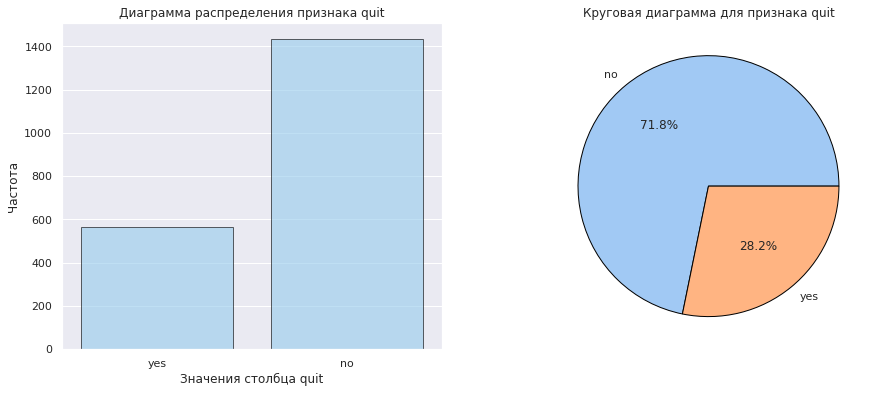

```python
cat_col_graphics(df_test_target_quit, 'quit')
```

Таким образом, в датасете *df_test_target_quit* признак имеет следующее распределение:

- **quit:** 28,2 процентов сотрудников компании уволились.

#### Портрет "уволившегося сотрудника"

Составим "портрет" уволившегося сотрудника. Для этого рассмотрим распределение признаков по данным об ушедших сотрудниках.

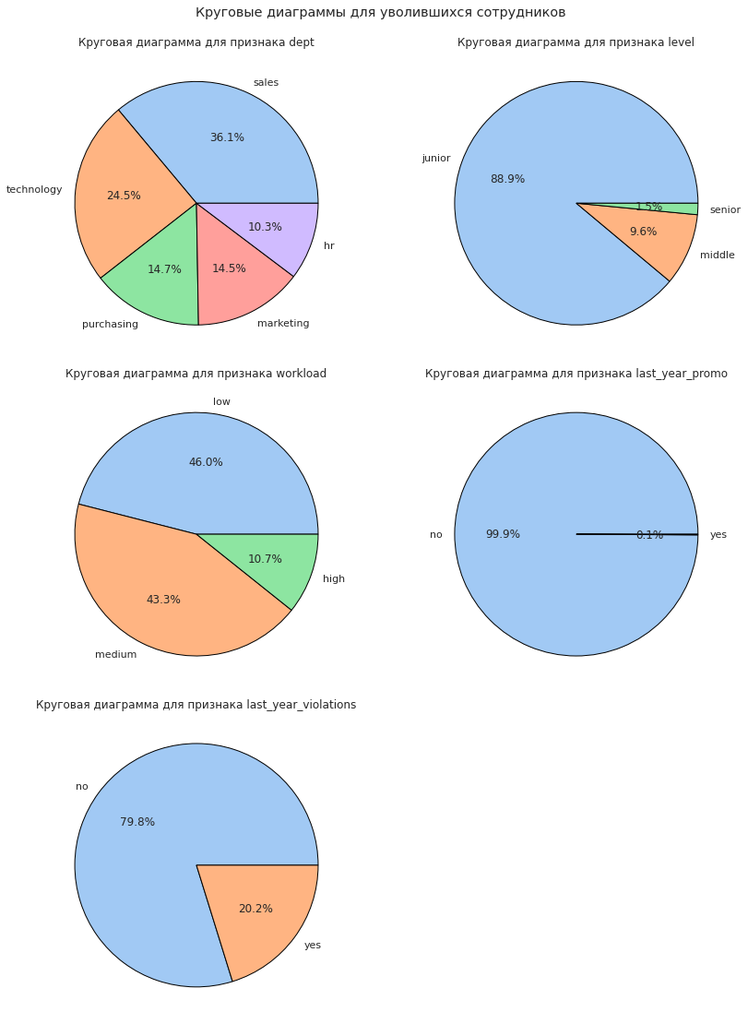

```python
df_quitted = df_train_quit.query('quit == "yes"')
df_non_quitted = df_train_quit.query('quit == "no"')

cat_cols = ['dept', 'level', 'workload', 'last_year_promo', 'last_year_violations']

fig, axes = plt.subplots(3, 2, figsize=(12, 16))

axes = axes.ravel()
plt.suptitle('Круговые диаграммы для уволившихся сотрудников\n')
for i in range(len(cat_cols)):
    df_quitted[cat_cols[i]].value_counts().plot.pie(ax=axes[i], autopct='%.1f%%',
                                        wedgeprops={'edgecolor': 'black', 'linewidth': 1})
    axes[i].set_title(f'Круговая диаграмма для признака {cat_cols[i]}')
    axes[i].set_ylabel('')
plt.tight_layout()
axes[5].set_visible(False)
```

```python
print(f"Средняя зарплата уволившегося сотрудника: {df_quitted['salary'].mean():.2f}")
print(f"Средняя заралата оставшегося сотрудника: {df_non_quitted['salary'].mean():.2f}")
```

```
Средняя зарплата уволившегося сотрудника: 23885.11
Средняя заралата оставшегося сотрудника: 37702.23
```

Таким образом, типичный ушедший сотрудник был из отдела продаж, он занимал младшую должность и имел низкую или среднюю нагрузку. Его зарплата была около 23,9 тысяч у.е и его не повышали в предыдуший год.

Построим наглядную гистограмму для ушедших и оставшихся сотрудников.

```python
df_test_target_quit.set_index('id', inplace=True)
df_target = df_test_target.join(df_test_target_quit)
df_target.head()
```

| id | job_satisfaction_rate | quit |
| --- | --- | --- |
| 130604 | 0.74 | no |
| 825977 | 0.75 | no |
| 418490 | 0.60 | yes |
| 555320 | 0.72 | no |
| 826430 | 0.08 | yes |

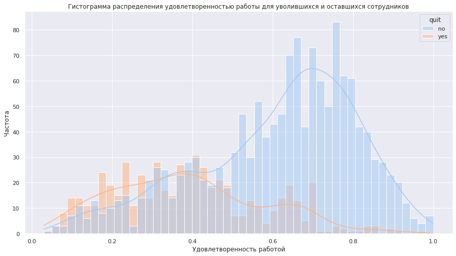

```python
plt.figure(figsize=(15, 8))
sns.histplot(data=df_target, x='job_satisfaction_rate', hue='quit', bins=50, kde=True)
plt.title('Гистограмма распределения удовлетворенностью работы для уволившихся и оставшихся сотрудников')
plt.xlabel('Удовлетворенность работой')
plt.ylabel('Частота');
```

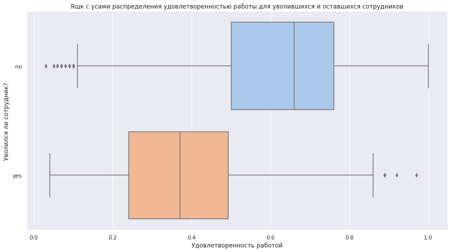

```python
plt.figure(figsize=(15, 8))
sns.boxplot(data=df_target, x='job_satisfaction_rate', y='quit')
plt.title('Ящк с усами распределения удовлетворенностью работы для уволившихся и оставшихся сотрудников')
plt.xlabel('Удовлетворенность работой')
plt.ylabel('Уволился ли сотрудник?');
```

Из гистограммы видно, что уровень удовлетворённости сотрудника работой в компании, действительно, влияет на то, уволится ли сотрудник, что подтверждает утверждения аналитиков.

#### Выводы по разделу

**Вывод:** Таким образом, в ходе исследовательского анализа данных были получены следующие результаты:

- Датасет *df_train_quit*:
  - **dept:** В компании 35,9% людей работают в отделе продаж, 23,2% - в технологическом отделе, 14,7% - в закупках, 14,6% - в отделе маркетинга и 11,6% - в отделе кадров;
  - **level:** 48,7% работников являются младшими сотрудниками, 42,4% сотрудников уровня middle и 8,9% старших сотрудников;
  - **workload:** 53% сотрудников имеют среднюю нагрузку, 30,2% - низкую и 16,8% - высокую;
  - **employment_years:** Средний стаж работы в компании - 3,7 лет, при этом максимальное значение - 10 лет. Медиана - 3 года;
  - **last_year_promo:** 2,8% сотрудников получили повышение за последний год;
  - **last_year_violations:** 13,6% процентов сотрудников нарушали трудовой договор за последний год;
  - **supervisor_evaluation:** Среднняя оценка качества работы сотрудника, которую дал руководитель - 3,47 со станд.отклонением - 1,00, медианное значение - 4.
  - **salary:** Средняя зарплата в компании - 33805,8 у.ед с большим станд.отклонением в 15152,4 у.ед. Минимальная зарплата - 12000 у.ед, максимальная - 96000 у.ед, медианное значение - 30000 у.ед.
  - **quit:** 28,2% сотрудников уволились из компании.
- Датасет *df_test_features_quit* оставлен без изменений.
- Датасет *df_test_target_quit*:
  - **quit:** 28,2 процентов сотрудников компании уволились.
- В ходе составления типичного "портрета" уволевшегося сотрудника было установлено, что типичный ушедший сотрудник был из отдела продаж, он занимал младшую должность и имел низкую или среднюю нагрузку. Его зарплата была около 23,9 тысяч у.е и его не повышали в предыдуший год.

### Корреляционный анализ

Рассчитаем значения корреляции хи-квадрат между признаками:

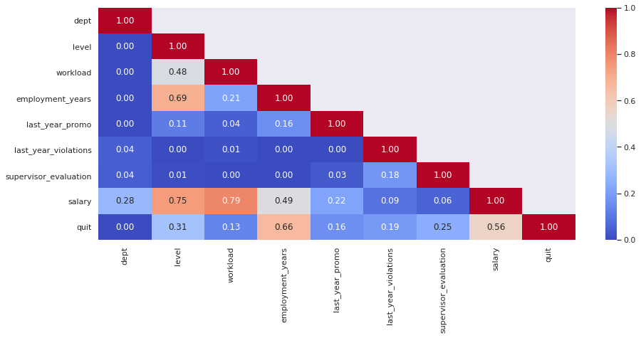

```python
phik_matrix(df_train_quit.drop('id', axis=1), list_of_interval_cols=['salary'])
```

Также построим две отдельные матрицы корреляции хи-квадрат для уволишихся и оставшихся сотрудников.

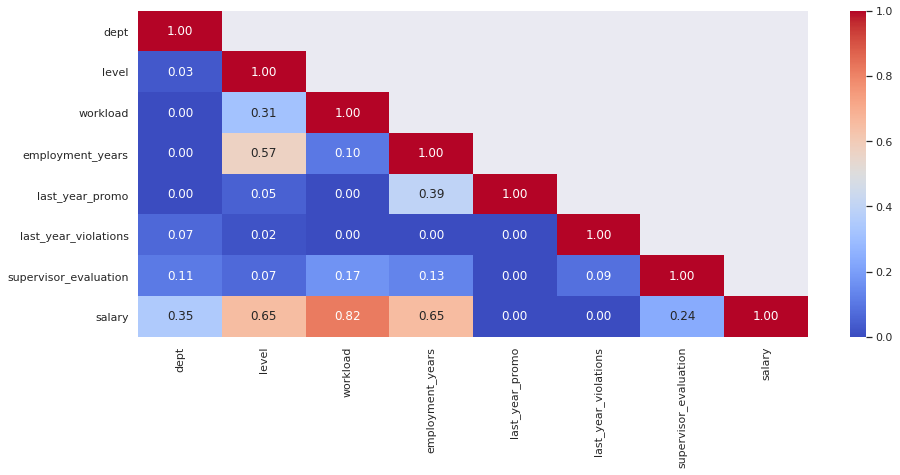

```python
phik_matrix(df_train_quit.drop('id', axis=1).query('quit == "yes"'), ['salary'])
```

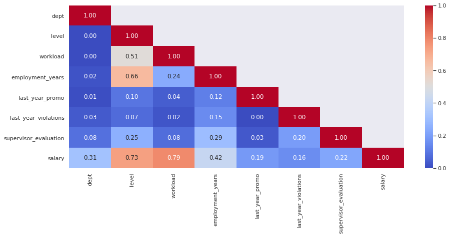

```python
phik_matrix(df_train_quit.drop('id', axis=1).query('quit == "no"'), ['salary'])
```

Так как все значения хи-квадрат менее 0,9, следовательно, мультиколлинеарности между признаками в датасете *df_train_quit* не обнаружено.

### Добавление признака

```python
df_train_quit.head()
```

|  | id | dept | level | workload | employment_years | last_year_promo | last_year_violations | supervisor_evaluation | salary | quit |
| --- | --- | --- | --- | --- | --- | --- | --- | --- | --- | --- |
| 0 | 723290 | sales | middle | high | 2 | no | no | 4 | 54000 | no |
| 1 | 814010 | sales | junior | medium | 2 | no | no | 4 | 27600 | no |
| 2 | 155091 | purchasing | middle | medium | 5 | no | no | 1 | 37200 | no |
| 3 | 257132 | sales | junior | medium | 2 | no | yes | 3 | 24000 | yes |
| 4 | 910140 | marketing | junior | medium | 2 | no | no | 5 | 25200 | no |

Добавим `job_satisfaction_rate`, предсказанный лучшей моделью первой задачи в датасет *df_train_quit*.

```python
df_train_quit.set_index('id', inplace=True)
df_train_quit['job_satisfaction_rate'] = gs.predict(df_train_quit).round(2)
df_train_quit.head()
```

| id | dept | level | workload | employment_years | last_year_promo | last_year_violations | supervisor_evaluation | salary | quit | job_satisfaction_rate |
| --- | --- | --- | --- | --- | --- | --- | --- | --- | --- | --- |
| 723290 | sales | middle | high | 2 | no | no | 4 | 54000 | no | 0.64 |
| 814010 | sales | junior | medium | 2 | no | no | 4 | 27600 | no | 0.84 |
| 155091 | purchasing | middle | medium | 5 | no | no | 1 | 37200 | no | 0.38 |
| 257132 | sales | junior | medium | 2 | no | yes | 3 | 24000 | yes | 0.38 |
| 910140 | marketing | junior | medium | 2 | no | no | 5 | 25200 | no | 0.69 |

Объединим датасеты *df_test_features* с *df_target* в один датасет *df_test_quit*.

```python
df_test_quit = df_test_features_quit.join(df_target)
df_test_quit.head()
```

| id | dept | level | workload | employment_years | last_year_promo | last_year_violations | supervisor_evaluation | salary | job_satisfaction_rate | quit |
| --- | --- | --- | --- | --- | --- | --- | --- | --- | --- | --- |
| 485046 | marketing | junior | medium | 2 | no | no | 5 | 28800 | 0.79 | no |
| 686555 | hr | junior | medium | 1 | no | no | 4 | 30000 | 0.72 | no |
| 467458 | sales | middle | low | 5 | no | no | 4 | 19200 | 0.64 | no |
| 418655 | sales | middle | low | 6 | no | no | 4 | 19200 | 0.60 | no |
| 789145 | hr | middle | medium | 5 | no | no | 5 | 40800 | 0.75 | no |

### Подготовка данных

```python
X_train = df_train_quit.drop('quit', axis=1)
y_train = df_train_quit['quit']

X_test = df_test_quit.drop('quit', axis=1)
y_test = df_test_quit['quit']
```

```python
ohe_columns = ['dept',
              'last_year_promo',
              'last_year_violations']

ord_columns = ['supervisor_evaluation',
              'workload',
              'level']

num_columns = ['employment_years',
              'salary',
              'job_satisfaction_rate']
```

```python
# replace_space_with_nan + SimpleImputer + OHE
ohe_pipe = Pipeline(
    [('replace_spaces', FunctionTransformer(replace_space_with_nan, feature_names_out='one-to-one')),
     ('simpleImputer_ohe', SimpleImputer(missing_values=np.nan, strategy='most_frequent')),
     ('ohe', OneHotEncoder(drop='first', handle_unknown='ignore', sparse=False))
    ]
)
# SimpleImputer + OE
ord_pipe = Pipeline(
    [('simpleImputer_before_ord', SimpleImputer(missing_values=np.nan, strategy='most_frequent')),
     ('ord',  OrdinalEncoder(categories=[
                    [1, 2, 3, 4, 5],
                    ['low', 'medium', 'high'],
                    ['junior', 'middle', 'sinior']],
                handle_unknown='use_encoded_value', unknown_value=np.nan)),
     ('simpleImputer_after_ord', SimpleImputer(missing_values=np.nan, strategy='most_frequent'))
    ]
)
```

```python
data_preprocessor = ColumnTransformer(
    [('ohe', ohe_pipe, ohe_columns),
     ('ord', ord_pipe, ord_columns),
     ('num', MinMaxScaler(), num_columns),
    ],
    remainder='passthrough'
)
```

```python
pipe_final = Pipeline([
    ('preprocessor', data_preprocessor),
    ('models', DecisionTreeClassifier(random_state=RANDOM_STATE))
])
```

```python
param_grid = [
    # словарь для модели DecisionTreeClassifier()
    {
        'models': [DecisionTreeClassifier(random_state=RANDOM_STATE)],
        'models__max_depth': range(2, 6),
        'models__max_features': range(2, 6),
        'preprocessor__num': [StandardScaler(), MinMaxScaler(), 'passthrough']
    },

    # словарь для модели KNeighborsClassifier()
    {
        'models': [KNeighborsClassifier()],
        'models__n_neighbors': range(2, 6),
        'preprocessor__num': [StandardScaler(), MinMaxScaler(), 'passthrough']
    },

    # словарь для модели LogisticRegression()
    {
        'models': [LogisticRegression(
            random_state=RANDOM_STATE,
            solver='liblinear',
            penalty='l1'
        )],
        'models__C': range(1, 5),
        'preprocessor__num': [StandardScaler(), MinMaxScaler(), 'passthrough']
    },

    # словарь для модели SVC()
    {
        'models': [SVC(
            random_state=RANDOM_STATE,
            kernel='poly',
            probability=True
        )],
        'models__C': range(1, 5),
        'models__degree': range(2, 4),
        'preprocessor__num': [StandardScaler(), MinMaxScaler(), 'passthrough']
    }
]
```

Для оценки качества работы модели используем ROC-AUC.

```python
gs2 = GridSearchCV(
    pipe_final,
    param_grid,
    cv=5,
    scoring='roc_auc',
    n_jobs=-1
)
gs2.fit(X_train, y_train)
```

```
GridSearchCV(cv=5,
             estimator=Pipeline(steps=[('preprocessor',
                                        ColumnTransformer(remainder='passthrough',
                                                          transformers=[('ohe',
                                                                         Pipeline(steps=[('replace_spaces',
                                                                                          FunctionTransformer(feature_names_out='one-to-one',
                                                                                                              func=<function replace_space_with_nan at 0x7f23cf677700>)),
                                                                                         ('simpleImputer_ohe',
                                                                                          SimpleImputer(strategy='most_frequent')),
                                                                                         ('ohe',
                                                                                          OneHotEncoder(dro...
                         {'models': [LogisticRegression(penalty='l1',
                                                        random_state=42,
                                                        solver='liblinear')],
                          'models__C': range(1, 5),
                          'preprocessor__num': [StandardScaler(),
                                                MinMaxScaler(),
                                                'passthrough']},
                         {'models': [SVC(C=4, kernel='poly', probability=True,
                                         random_state=42)],
                          'models__C': range(1, 5),
                          'models__degree': range(2, 4),
                          'preprocessor__num': [StandardScaler(),
                                                MinMaxScaler(),
                                                'passthrough']}],
             scoring='roc_auc')
```

```python
print('Лучшая модель и её параметры:\n\n', gs2.best_estimator_)
print ('Метрика лучшей модели при кросс-валидации:', round(gs2.best_score_, 3))
```

```
Лучшая модель и её параметры:

 Pipeline(steps=[('preprocessor',
                 ColumnTransformer(remainder='passthrough',
                                   transformers=[('ohe',
                                                  Pipeline(steps=[('replace_spaces',
                                                                   FunctionTransformer(feature_names_out='one-to-one',
                                                                                       func=<function replace_space_with_nan at 0x7f23cf677700>)),
                                                                  ('simpleImputer_ohe',
                                                                   SimpleImputer(strategy='most_frequent')),
                                                                  ('ohe',
                                                                   OneHotEncoder(drop='first',
                                                                                 handle_unknown='ig...
                                                                                              ['junior',
                                                                                               'middle',
                                                                                               'sinior']],
                                                                                  handle_unknown='use_encoded_value',
                                                                                  unknown_value=nan)),
                                                                  ('simpleImputer_after_ord',
                                                                   SimpleImputer(strategy='most_frequent'))]),
                                                  ['supervisor_evaluation',
                                                   'workload', 'level']),
                                                 ('num', StandardScaler(),
                                                  ['employment_years', 'salary',
                                                   'job_satisfaction_rate'])])),
                ('models',
                 SVC(C=4, kernel='poly', probability=True, random_state=42))])
Метрика лучшей модели при кросс-валидации: 0.929
```

```python
y_test_proba = gs2.predict_proba(X_test)
print('Метрика ROC-AUC на тестовой выборке:', round(roc_auc_score(y_test, y_test_proba[:,1]), 3))
```

```
Метрика ROC-AUC на тестовой выборке: 0.925
```

**Вывод:**

В ходе моделирования была найдена и обучена модель для предсказания увольнения сотрудника из компании. Лучшие результаты показала модель метода опорных векторов **SVC(C=4, kernel='poly', probability=True, random_state=42)**. Её показатели метрики roc-auc для тренировочной выборки - 0.929, для тестовой выборки - 0.925. Это хорошие показатели, означающие, что модель хорошо справляется со своей задачей.

### Анализ важности признаков

Для анализа важности признаков воспользуемся SHAP значениями. Т.к SVC модель имеет полиномиальное ядро, используем KernelExplainer и ограничимся 40 образцами строк.

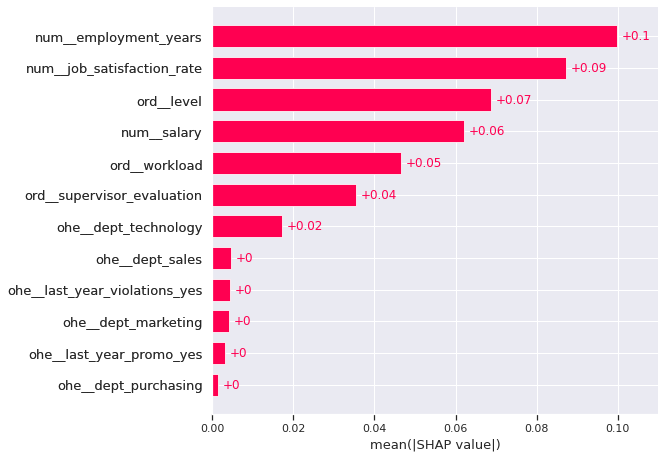

```
None
```

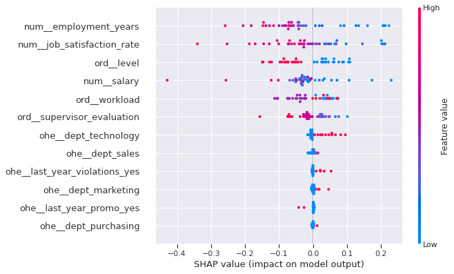

```python
X_train_2 = gs2.best_estimator_.named_steps['preprocessor'].transform(X_train)
explainer2 = shap.KernelExplainer(
    lambda x: gs2.best_estimator_.named_steps['models'].predict_proba(x)[:,1], shap.sample(
        X_train_2, 40, random_state=RANDOM_STATE))

X_test_2 = gs2.best_estimator_.named_steps['preprocessor'].transform(X_test)

feature_names = gs2.best_estimator_.named_steps['preprocessor'].get_feature_names_out()

X_test_2 = pd.DataFrame(X_test_2, columns=feature_names)

shap_values = explainer2(shap.sample(X_test_2, 40, random_state=RANDOM_STATE))

display(shap.plots.bar(shap_values, max_display=15))
shap.plots.beeswarm(shap_values, max_display=15)
```

Наиболее важные признаки - `employment_years`, `job_satisfaction_rate`, `level` и `salary`.

Признаки, имеющие незначительное влияние на модель - `dept`, `last_year_promo`, `last_year_violations`.

### Выводы

Целью исследования было построить модель, которая сможет на основе данных заказчика предсказать то, что сотрудник уволится из компании.

В ходе исследования были выполнены следующие шаги:

1. **Загрузка данных:**
   - В датасете *df_train_quit* 4000 строчек и 10 признаков. У столбцов `id`, `employment_years`, `supervisor_evaluation`, `salary` тип данных int64, у остальных - object. Пропусков в данных нет.
   - В датасете *df_test_target_quit* 2000 строчек и 2 признака. У столбца `id` тип данных int64, у `quit` - object. Пропусков в данных нет.
2. **Предобработка данных:**
   - В датасете *df_train_quit* было заменено значение **sinior** на **senior** в столбце `level`. Полных строк-дубликатов найдено не было;
   - В датасете *df_test_features_quit* все оставлено без изменений;
   - В датасете *df_test_target_quit* полных строк-дубликатов найдено не было.
3. **Исследовательский анализ:**
   - Датасет *df_train_quit*:
     - **dept:** В компании 35,9% людей работают в отделе продаж, 23,2% - в технологическом отделе, 14,7% - в закупках, 14,6% - в отделе маркетинга и 11,6% - в отделе кадров;
     - **level:** 48,7% работников являются младшими сотрудниками, 42,4% сотрудников уровня middle и 8,9% старших сотрудников;
     - **workload:** 53% сотрудников имеют среднюю нагрузку, 30,2% - низкую и 16,8% - высокую;
     - **employment_years:** Средний стаж работы в компании - 3,7 лет, при этом максимальное значение - 10 лет. Медиана - 3 года;
     - **last_year_promo:** 2,8% сотрудников получили повышение за последний год;
     - **last_year_violations:** 13,6% процентов сотрудников нарушали трудовой договор за последний год;
     - **supervisor_evaluation:** Среднняя оценка качества работы сотрудника, которую дал руководитель - 3,47 со станд.отклонением - 1,00, медианное значение - 4.
     - **salary:** Средняя зарплата в компании - 33805,8 у.ед с большим станд.отклонением в 15152,4 у.ед. Минимальная зарплата - 12000 у.ед, максимальная - 96000 у.ед, медианное значение - 30000 у.ед.
     - **quit:** 28,2% сотрудников уволились из компании.
   - Датасет *df_test_features_quit* оставлен без изменений.
   - Датасет *df_test_target_quit*:
     - **quit:** 28,2 процентов сотрудников компании уволились.
   - В ходе составления типичного "портрета" уволевшегося сотрудника было установлено, что типичный ушедший сотрудник был из отдела продаж, он занимал младшую должность и имел низкую или среднюю нагрузку. Его зарплата была около 23,9 тысяч у.е и его не повышали в предыдуший год.
4. **Корреляционный анализ:**

Мультиколлинеарности в данных не обнаружено, т.к. все значения корреляции хи-квадрат меньше 0,9.

5. **Подготовка и обучение моделей:**

В ходе моделирования была найдена и обучена модель для предсказания увольнения сотрудника из компании. Лучшие результаты показала модель метода опорных векторов **SVC(C=4, kernel='poly', probability=True, random_state=42)**. Её показатели метрики roc-auc для тренировочной выборки - 0.929, для тестовой выборки - 0.925. Это хорошие показатели, означающие, что модель хорошо справляется со своей задачей.

6. **Анализ важности признаков:**

Наиболее важные признаки - `employment_years`, `job_satisfaction_rate`, `level` и `salary`.

Признаки, имеющие незначительное влияние на модель - `dept`, `last_year_promo`, `last_year_violations`.